title: “Pep2” author: “Joaquín Saldivia, Lucas Mesias” date: “2023-07-18” output: html_document —

# PEP 2

1. Recolección de datos (10 puntos). Descargar los datos y combinar los archivos en un único csv. Definir y aplicar una estrategia para tratar los datos con valores faltantes, en caso de haber. Finalmente, guardar el archivo único en formato csv.

```r
# Obtén la lista de archivos CSV en tu directorio
archivos <- list.files(path = "PROCESADOS", pattern = "*.csv", full.names = TRUE)

# Crea un dataframe vacío para almacenar los datos
datos_combinados <- lapply(archivos, read.csv, header=TRUE) %>% bind_rows()

# Guarda los datos combinados en un nuevo archivo CSV
write.csv(datos_combinados, "datos_combinados.csv", row.names = FALSE)
```

No se encuentran datos faltantes o iguales a NA

2. Organización y clasificación de los datos (10 puntos). Utilizando el archivo csv único creado, generar una tabla que describa cualitativamente cada una de las variables, clasificándolas desde una perspectiva estadística.

```r
# Obtener la frecuencia de cada dato en todas las columnas
obtener_frecuencia <- function(arg) {
  frecuencia_columna <- table(arg)
  resultado <- data.frame(Nombre = names(frecuencia_columna), Cantidad = as.vector(frecuencia_columna))
  return(resultado)
}

frecuenciaEstamento = obtener_frecuencia(datos_combinados$Estamento)
frecuenciaGrado = obtener_frecuencia(datos_combinados$Grado)
frecuenciaTituloOficio = obtener_frecuencia(datos_combinados$Titulo.Oficio)
frecuenciaFuncionCargo = obtener_frecuencia(datos_combinados$Funcion.Cargo)
frecuenciaUnidad = obtener_frecuencia(datos_combinados$Unidad)
frecuenciaBrutoHaber = obtener_frecuencia(datos_combinados$BrutoHaber)
```

Grado: Cualitativa Ordinal Estamento: Cualitativa Nominal Titulo Oficio: Cualitativa Nominal Funcion Cargo: Cualitativa Nominal Unidad: Cualitativa Nominal Bruto Haber: Cuantitativa Discreta

3. Análisis descriptivo (25 puntos). Estudiar la distribución de frecuencia de las variables “Estamento”, “Unidad”, “Grado” y “Bruto Haber” (Remuneración). Utilizar gráficos o tablas para las variables cualitativas e histogramas para las variables cuantitativas. Si hay muchas categorías para las variables cualitativas, limítese a las 10 más frecuentes. En el caso de la remuneración, incluir el estudio de las medidas estadísticas.

```r
describir_variable_cualitativa <- function(variable) {
  top_10_mas_repetidos <- variable %>%
  arrange(desc(Cantidad)) %>%
  head(10)
  print(top_10_mas_repetidos)
}

# Función para describir variables cuantitativas y generar histogramas
describir_variable_cuantitativa <- function(variable) {
  ggplot(data = variable, aes(x = Nombre, y = Cantidad)) +
        geom_bar(stat = "identity", fill = "aquamarine") +
        labs(title = "Frecuencia de datos", x = "Dato", y = "Frecuencia")
}

Mode <- function(x){
      ux <- unique(x)
      ux[which.max(tabulate(match(x, ux)))]
}

describir_variable_cualitativa(frecuenciaEstamento)
```

```
##                  Nombre Cantidad
## 1 PROFESOR HORAS CLASES     3385
## 2         PROFESIONALES      886
## 3        ADMINISTRATIVO      613
## 4            ACADEMICOS      575
## 5               TECNICO      336
## 6            AUXILIARES      188
## 7   MEDICOS Y DENTISTAS        4
```

```r
describir_variable_cualitativa(frecuenciaTituloOficio)
```

```
##                                            Nombre Cantidad
## 1                                     HORAS CLASE      491
## 2                                       PSICOLOGO      155
## 3  PROFESOR DE ESTADO EN MATEMATICA Y COMPUTACION      118
## 4         TECNOLOGO EN ADMINISTRACION DE PERSONAL       94
## 5                                      PERIODISTA       91
## 6                                       SOCIOLOGO       91
## 7                              PROFESOR DE INGLES       90
## 8                                 MEDICO CIRUJANO       85
## 9                                      ABOGADO(A)       83
## 10                 INGENIERO CIVIL EN INFORMATICA       80
```

```r
describir_variable_cualitativa(frecuenciaFuncionCargo)
```

```
##                         Nombre Cantidad
## 1                  HORAS CLASE     3143
## 2                    ACADEMICO      470
## 3                  PROFESIONAL      221
## 4  SECRETARIA DE APOYO DOCENTE       98
## 5     ENCARGADO DE LABORATORIO       96
## 6        AUXILIAR DE SERVICIOS       78
## 7          JEFE DE LABORATORIO       71
## 8              JEFE DE SECCION       64
## 9    SECRETARIA ADMINISTRATIVA       64
## 10     ASISTENTE DE MANTENCION       61
```

```r
describir_variable_cualitativa(frecuenciaGrado)
```

```
##    Nombre Cantidad
## 1     S/G     3389
## 2       6      355
## 3      17      317
## 4       8      252
## 5      10      233
## 6       4      202
## 7      12      161
## 8      13      142
## 9      14      126
## 10     20      114
```

```r
describir_variable_cualitativa(frecuenciaUnidad)
```

```
##                            Nombre Cantidad
## 1     DPTO MAT. Y CS. DE LA COMP.      407
## 2   DPTO LINGUISTICA Y LITERATURA      348
## 3  DPTO. TECNOLOGIAS INDUSTRIALES      209
## 4             ESCUELA DE MEDICINA      188
## 5       DEPARTAMENTO DE EDUCACIÓN      187
## 6     DPTO  INGENIERIA INDUSTRIAL      173
## 7       DPTO INGENIERIA ELECTRICA      160
## 8               DEPTO DE HISTORIA      155
## 9        DPTO INGENIERIA EN MINAS      154
## 10     DPTO INGENIERIA GEOGRAFICA      148
```

[figure not shown]

```r
describir_variable_cuantitativa(frecuenciaBrutoHaber)
```

```r
summary(datos_combinados$BrutoHaber)
```

```
##    Min. 1st Qu.  Median    Mean 3rd Qu.    Max.
##      48  261026  587764  848637 1041632 6450387
```

```r
print(Mode(datos_combinados$BrutoHaber))
```

```
## [1] 191994
```

4. Análisis inferencial (25 puntos). En este punto, concéntrate en dos aspectos:

4.1. La Fundación Sol ha señalado en su estudio publicado el 2021 que sólo el 2% de la población chile gana más de $2.5 millones de pesos (Durán and Kremerman 2021). ¿La remuneración media o mediana de los académicos a contrata de la USACH está dentro de este 2% poblacional?

```r
datos = filter(datos_combinados, Estamento == "ACADEMICOS")
datosSueldo = datos$BrutoHaber
shapiro.test(datosSueldo)$p.value
```

```
## [1] 1.23496e-15
```

```r
lillie.test(datosSueldo)$p.value
```

```
## [1] 1.799892e-59
```

```r
ad.test(datosSueldo)$p.value
```

```
## [1] 3.7e-24
```

```r
cvm.test(datosSueldo)$p.value
```

```
## [1] 7.37e-10
```

```r
wilcox.test(datosSueldo, mu=2500000, conf.int=0.95, alternative = "greater")
```

```
##
##  Wilcoxon signed rank test with continuity correction
##
## data:  datosSueldo
## V = 122206, p-value < 2.2e-16
## alternative hypothesis: true location is greater than 2500000
## 95 percent confidence interval:
##  2830536     Inf
## sample estimates:
## (pseudo)median
##        2863166
```

los test arrojan que no se sigue una distribución normal, por lo que se hace un test no paramétrico de una muestra.

4.2. ¿Cómo responde un modelo de regresión lineal simple en términos de calidad en relación a estas dos variables: grado y remuneración? Existen relaciones directas entre el grado de los funcionarios y su remuneración.

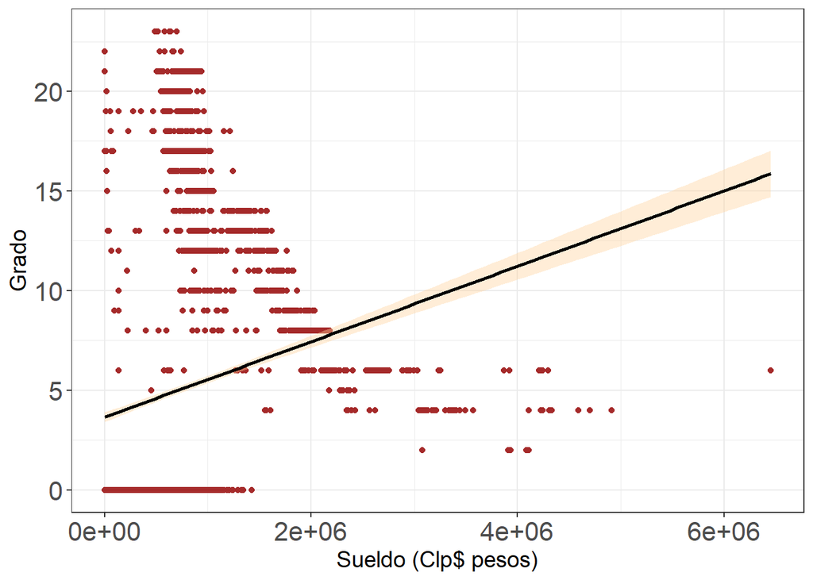

```r
# Cambiar todos los valores "S/G" por 0 en una columna del dataframe
datos_combinados$Grado <- ifelse(datos_combinados$Grado == "S/G", 0, datos_combinados$Grado)
datos_combinados$Grado <- as.integer(datos_combinados$Grado)

filterdata = subset(datos_combinados, Grado > 0)

regresion = lm(Grado ~ BrutoHaber, data = subset(datos_combinados, Grado > 0))

g11 = ggplot(datos_combinados,aes(x=BrutoHaber,y=Grado))
g11 = g11 + geom_point(aes(x=BrutoHaber,y=Grado),datos_combinados,color="brown")
g11 = g11 + theme_bw() + ylab("Grado")
g11 = g11 + xlab("Sueldo (Clp$ pesos)")
g11 = g11 + theme(axis.text = element_text(size = 16),
 axis.title.x = element_text(size = 14),
 axis.title.y = element_text(size = 14))
g11 = g11 + geom_smooth(method = "lm",level = 0.95, color = "black", fill =
"burlywood1")
#Grafico
plot(g11)
```

```r
#Resultado
regresion
```

```
##
## Call:
## lm(formula = Grado ~ BrutoHaber, data = subset(datos_combinados,
##     Grado > 0))
##
## Coefficients:
## (Intercept)   BrutoHaber
##   1.904e+01   -4.752e-06
```

Se cambian los Sin grado por 0 para poder continuar con el modelo, este valor es elegido ya que en la medicion de grados no esta contemplado el grado 0.

Ademas luego esto los que tenga grado 0 no se consideran en la regresión ya que estan fuera del intervalo.

5. Analisis de resultados (20 puntos). Analizar los resultados obtenidos en las etapas 3 y 4 desde el punto de vista de la problemática.

6. Toma de decisiones (10 puntos). Si fuese parte del equipo gestor de recursos humanos de la universidad, ¿qué decisiones tomaría con base a los resultados obtenidos?

Se podria hacer un ajuste de sueldos para que la ganancia de cada funcionario sea acorde a su grado respectivo.

# Referencia

OpenAI. (2021). ChatGPT [Software]. Disponible en: https://openai.com